# Test-Retest Etibarlılığı

# 5 Praktik Tətbiq və Nümunələr

## 5.1 Real Test Ssenariləri

```r
# Müxtəlif test növləri üçün real ssenari simulyasiyası

# Ssenari 1: Zəka Testi (WAIS-IV tipli)
set.seed(111)
iq_participants <- 120
iq_true_scores <- rnorm(iq_participants, 100, 15)

# 3 həftə arayla tətbiq
iq_test1 <- iq_true_scores + rnorm(iq_participants, 0, 7)
iq_practice_effect <- rnorm(iq_participants, 2, 3)  # Kiçik təcrübə effekti
iq_test2 <- iq_true_scores + iq_practice_effect + rnorm(iq_participants, 0, 7)

# Ssenari 2: Şəxsiyyət Testi (Big Five tipli)
personality_participants <- 150
personality_true_scores <- rnorm(personality_participants, 50, 10)

# 6 həftə arayla tətbiq
personality_test1 <- personality_true_scores + rnorm(personality_participants, 0, 5)
personality_change <- rnorm(personality_participants, 0, 2)  # Kiçik həqiqi dəyişmə
personality_test2 <- (personality_true_scores + personality_change) +
                    rnorm(personality_participants, 0, 5)

# Ssenari 3: Akademik Bacarıq Testi
academic_participants <- 100
academic_true_scores <- rnorm(academic_participants, 75, 12)

# 2 həftə arayla tətbiq
academic_test1 <- academic_true_scores + rnorm(academic_participants, 0, 8)
academic_learning <- rnorm(academic_participants, 4, 2)  # Güclü öyrənmə effekti
academic_test2 <- academic_true_scores + academic_learning +
                  rnorm(academic_participants, 0, 8)

# Nəticələri toplama
scenario_results <- data.frame(
  Test_Novi = c("Zəka Testi", "Şəxsiyyət Testi", "Akademik Bacarıq"),
  n = c(iq_participants, personality_participants, academic_participants),
  Interval = c("3 həftə", "6 həftə", "2 həftə"),

  Test1_Orta = c(round(mean(iq_test1), 1), round(mean(personality_test1), 1),
                round(mean(academic_test1), 1)),
  Test2_Orta = c(round(mean(iq_test2), 1), round(mean(personality_test2), 1),
                round(mean(academic_test2), 1)),

  Orta_Deyisme = c(round(mean(iq_test2 - iq_test1), 2),
                  round(mean(personality_test2 - personality_test1), 2),
                  round(mean(academic_test2 - academic_test1), 2)),

  Test_Retest_r = c(round(cor(iq_test1, iq_test2), 3),
                   round(cor(personality_test1, personality_test2), 3),
                   round(cor(academic_test1, academic_test2), 3)),

  Qiymetlendirme = c("Qəbul edilə bilər", "Yaxşı", "Problemli (öyrənmə)")
)

kable(scenario_results, caption = "Real Test Ssenarilərində Test-Retest Nəticələri")
```

Real Test Ssenarilərində Test-Retest Nəticələri

[output not shown]

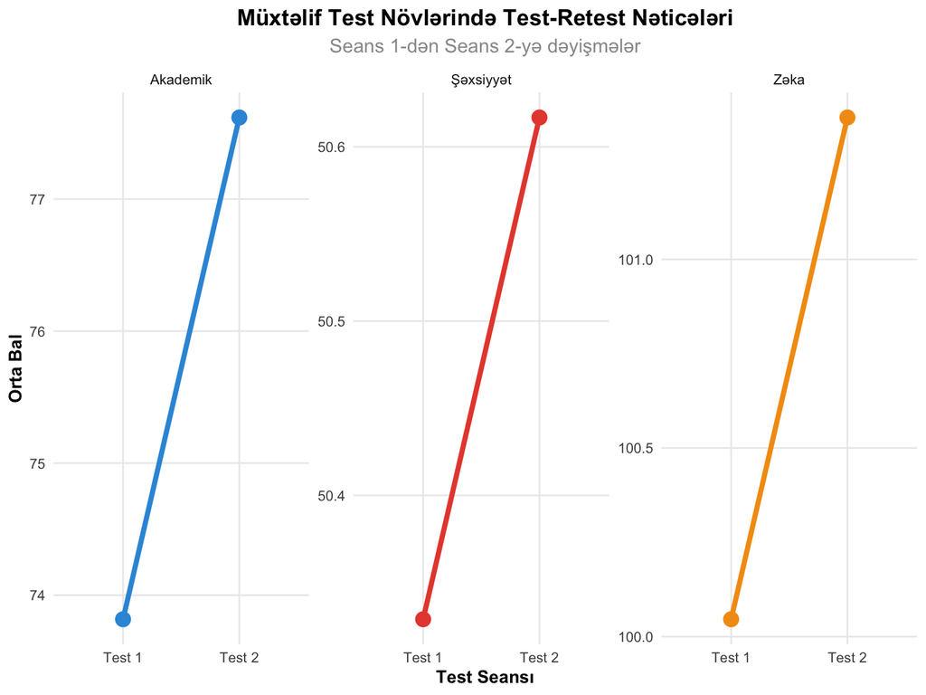

```r
# Ssenarilərın vizual müqayisəsi
scenario_long <- data.frame(
  Test_Novi = rep(c("Zəka", "Şəxsiyyət", "Akademik"), each = 2),
  Seans = rep(c("Test 1", "Test 2"), 3),
  Orta_Bal = c(mean(iq_test1), mean(iq_test2),
               mean(personality_test1), mean(personality_test2),
               mean(academic_test1), mean(academic_test2))
)

ggplot(scenario_long, aes(x = Seans, y = Orta_Bal, group = Test_Novi, color = Test_Novi)) +
  geom_line(size = 1.5) +
  geom_point(size = 4) +
  facet_wrap(~Test_Novi, scales = "free_y") +
  scale_color_manual(values = colors_basic[1:3]) +
  labs(title = "Müxtəlif Test Növlərində Test-Retest Nəticələri",
       subtitle = "Seans 1-dən Seans 2-yə dəyişmələr",
       x = "Test Seansı", y = "Orta Bal") +
  theme_clean() +
  theme(legend.position = "none")
```

## 5.2 R-da Test-Retest Analizi

```r
# Hərtərəfli test-retest analizi funksiyası

conduct_test_retest_analysis <- function(test1_scores, test2_scores,
                                       test_name = "Test", alpha = 0.05) {

  # Əsas statistikalar
  n <- length(test1_scores)
  mean1 <- mean(test1_scores)
  mean2 <- mean(test2_scores)
  sd1 <- sd(test1_scores)
  sd2 <- sd(test2_scores)

  # Test-retest korrelyasiyası
  tr_cor <- cor(test1_scores, test2_scores)
  tr_test <- cor.test(test1_scores, test2_scores)

  # Orta fərq (təcrübə effekti)
  mean_diff <- mean(test2_scores - test1_scores)
  diff_test <- t.test(test1_scores, test2_scores, paired = TRUE)

  # Effect size (Cohen's d)
  pooled_sd <- sqrt((sd1^2 + sd2^2) / 2)
  cohens_d <- mean_diff / pooled_sd

  # Standart ölçmə xətası
  sem1 <- sd1 * sqrt(1 - tr_cor)
  sem2 <- sd2 * sqrt(1 - tr_cor)

  # Nəticələr
  results <- list(
    test_name = test_name,
    n = n,
    descriptives = data.frame(
      Test = c("Test 1", "Test 2"),
      Mean = round(c(mean1, mean2), 2),
      SD = round(c(sd1, sd2), 2),
      SEM = round(c(sem1, sem2), 2)
    ),
    reliability = round(tr_cor, 3),
    reliability_ci = round(tr_test$conf.int, 3),
    reliability_p = tr_test$p.value,
    mean_difference = round(mean_diff, 2),
    difference_p = diff_test$p.value,
    effect_size = round(cohens_d, 2),
    interpretation = list(
      reliability = ifelse(tr_cor >= 0.9, "Əla",
                          ifelse(tr_cor >= 0.8, "Yaxşı",
                                ifelse(tr_cor >= 0.7, "Qəbul edilə bilər", "Zəif"))),
      practice_effect = ifelse(abs(cohens_d) >= 0.8, "Böyük",
                              ifelse(abs(cohens_d) >= 0.5, "Orta",
                                    ifelse(abs(cohens_d) >= 0.2, "Kiçik", "Cüzi")))
    )
  )

  return(results)
}

# Nümunə analiz
example_analysis <- conduct_test_retest_analysis(
  test1_scores = iq_test1,
  test2_scores = iq_test2,
  test_name = "Zəka Testi"
)

# Nəticələri göstər
cat("=== TEST-RETEST ANALİZİ ===\n")
```

```
## === TEST-RETEST ANALİZİ ===
```

```r
cat("Test:", example_analysis$test_name, "\n")
```

```
## Test: Zəka Testi
```

```r
cat("Nümunə ölçüsü:", example_analysis$n, "\n\n")
```

```
## Nümunə ölçüsü: 120
```

```r
print(kable(example_analysis$descriptives, caption = "Təsviri Statistikalar"))
```

```
##
##
## Table: Təsviri Statistikalar
##
## |Test   |   Mean|    SD|  SEM|
## |:------|------:|-----:|----:|
## |Test 1 | 100.05| 17.60| 6.96|
## |Test 2 | 101.38| 17.67| 6.99|
```

```r
cat("\n=== ETİBARLILIQ ===\n")
```

```
##
## === ETİBARLILIQ ===
```

```r
cat("Test-retest r:", example_analysis$reliability, "\n")
```

```
## Test-retest r: 0.843
```

```r
cat("95% Etimad aralığı: [", example_analysis$reliability_ci[1], ", ",
    example_analysis$reliability_ci[2], "]\n")
```

```
## 95% Etimad aralığı: [ 0.783 ,  0.888 ]
```

```r
cat("p-dəyəri:", format(example_analysis$reliability_p, scientific = TRUE), "\n")
```

```
## p-dəyəri: 1.226499e-33
```

```r
cat("Qiymətləndirmə:", example_analysis$interpretation$reliability, "\n\n")
```

```
## Qiymətləndirmə: Yaxşı
```

```r
cat("=== TƏCRÜBƏ EFFEKTİ ===\n")
```

```
## === TƏCRÜBƏ EFFEKTİ ===
```

```r
cat("Orta fərq:", example_analysis$mean_difference, "\n")
```

```
## Orta fərq: 1.33
```

```r
cat("Cohen's d:", example_analysis$effect_size, "\n")
```

```
## Cohen's d: 0.08
```

```r
cat("p-dəyəri:", format(example_analysis$difference_p, scientific = TRUE), "\n")
```

```
## p-dəyəri: 1.423862e-01
```

```r
cat("Qiymətləndirmə:", example_analysis$interpretation$practice_effect, "\n")
```

```
## Qiymətləndirmə: Cüzi
```

# 6 Test-Retest Metodunun Alternativləri

## 6.1 Digər Etibarlılıq Metodları ilə Müqayisə

```r
# Etibarlılıq metodlarının müqayisəsi

reliability_methods <- data.frame(
  Metod = c("Test-Retest", "Paralel Formalar", "Split-Half", "Cronbach Alpha", "KR-20"),

  Olcduyu = c("Stabillik", "Ekvivalentlik", "Daxili tutarlılıq", "Daxili tutarlılıq", "Daxili tutarlılıq"),

  Ustunluk = c("Həqiqi stabillik", "Təcrübə yox", "Tez və asan", "Tez və asan", "İkili məlumat"),

  Catismazliq = c("Təcrübə/yaddaş", "2 forma lazım", "Təsadüfi bölgü", "Homojenlik tələbi", "Yalnız 0/1"),

  Tetbiq_Vaxt = c("Uzun", "Orta", "Qısa", "Qısa", "Qısa"),
  Tetbiq_Catinlik = c("Yüksək", "Orta", "Aşağı", "Aşağı", "Aşağı"),

  Min_Etibarlilik = c(0.75, 0.80, 0.70, 0.70, 0.70),
  Ideal_Etibarlilik = c(0.85, 0.90, 0.80, 0.80, 0.80)
)

kable(reliability_methods, caption = "Etibarlılıq Metodlarının Hərtərəfli Müqayisəsi")
```

Etibarlılıq Metodlarının Hərtərəfli Müqayisəsi

| Metod | Olcduyu | Ustunluk | Catismazliq | Tetbiq_Vaxt | Tetbiq_Catinlik | Min_Etibarlilik | Ideal_Etibarlilik |
| --- | --- | --- | --- | --- | --- | --- | --- |
| Test-Retest | Stabillik | Həqiqi stabillik | Təcrübə/yaddaş | Uzun | Yüksək | 0.75 | 0.85 |
| Paralel Formalar | Ekvivalentlik | Təcrübə yox | 2 forma lazım | Orta | Orta | 0.80 | 0.90 |
| Split-Half | Daxili tutarlılıq | Tez və asan | Təsadüfi bölgü | Qısa | Aşağı | 0.70 | 0.80 |
| Cronbach Alpha | Daxili tutarlılıq | Tez və asan | Homojenlik tələbi | Qısa | Aşağı | 0.70 | 0.80 |
| KR-20 | Daxili tutarlılıq | İkili məlumat | Yalnız 0/1 | Qısa | Aşağı | 0.70 | 0.80 |

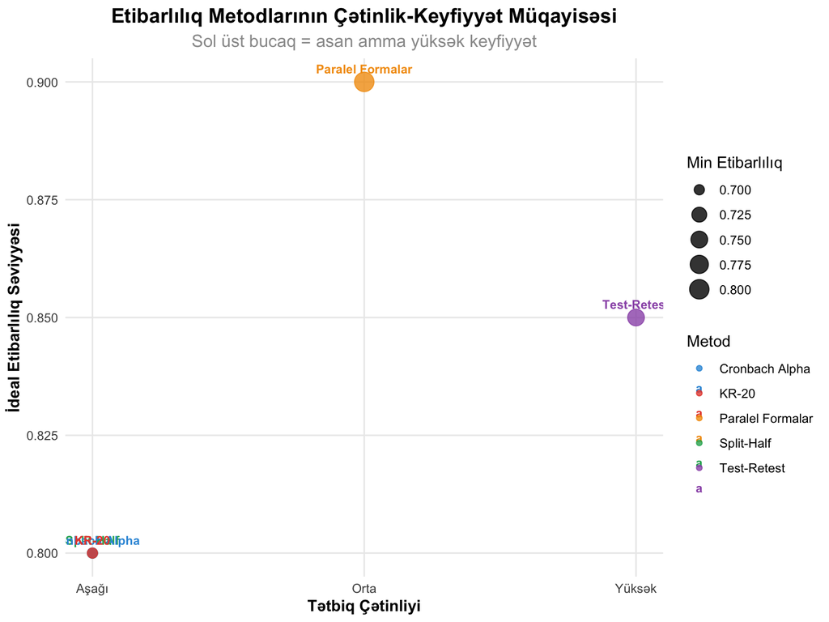

```r
# Metodların güclü və zəif tərəfləri
method_comparison <- reliability_methods %>%
  select(Metod, Tetbiq_Catinlik, Min_Etibarlilik, Ideal_Etibarlilik) %>%
  mutate(
    Tetbiq_Catinlik_Numeric = ifelse(Tetbiq_Catinlik == "Aşağı", 1,
                                    ifelse(Tetbiq_Catinlik == "Orta", 2, 3))
  )

ggplot(method_comparison, aes(x = Tetbiq_Catinlik_Numeric, y = Ideal_Etibarlilik,
                             color = Metod, size = Min_Etibarlilik)) +
  geom_point(alpha = 0.8) +
  geom_text(aes(label = Metod), vjust = -1, hjust = 0.5, size = 3, fontface = "bold") +
  scale_color_manual(values = colors_basic) +
  scale_size_continuous(range = c(3, 6), name = "Min Etibarlılıq") +
  scale_x_continuous(breaks = 1:3, labels = c("Aşağı", "Orta", "Yüksək")) +
  labs(title = "Etibarlılıq Metodlarının Çətinlik-Keyfiyyət Müqayisəsi",
       subtitle = "Sol üst bucaq = asan amma yüksək keyfiyyət",
       x = "Tətbiq Çətinliyi", y = "İdeal Etibarlılıq Səviyyəsi") +
  theme_clean()
```

## 6.2 Test-Retest Metodunun Seçimi

```r
# Test-retest metodunun seçilməsi üçün qərar ağacı

decision_criteria <- data.frame(
  Kriteriya = c("Stabillik əsas məqsəd", "Zaman var", "Eyni qrup əlçatan",
                "Təcrübə effekti minimal", "Paralel forma yox", "Həqiqi dəyişmə yavaş"),

  Ehemiyyeti = c("Yüksək", "Orta", "Yüksək", "Yüksək", "Orta", "Yüksək"),

  Test_Retest_Uygun = c("Bəli", "Bəli", "Bəli", "Bəli", "Bəli", "Bəli"),

  Alternativ_Tovsiye = c("Yox", "Split-half", "Paralel formalar",
                        "Paralel formalar", "Alpha/KR-20", "Qısa interval")
)

kable(decision_criteria, caption = "Test-Retest Seçimi üçün Qərar Meyarları")
```

Test-Retest Seçimi üçün Qərar Meyarları

| Kriteriya | Ehemiyyeti | Test_Retest_Uygun | Alternativ_Tovsiye |
| --- | --- | --- | --- |
| Stabillik əsas məqsəd | Yüksək | Bəli | Yox |
| Zaman var | Orta | Bəli | Split-half |
| Eyni qrup əlçatan | Yüksək | Bəli | Paralel formalar |
| Təcrübə effekti minimal | Yüksək | Bəli | Paralel formalar |
| Paralel forma yox | Orta | Bəli | Alpha/KR-20 |
| Həqiqi dəyişmə yavaş | Yüksək | Bəli | Qısa interval |

```r
# Test növü üzrə tövsiyələr
test_type_recommendations <- data.frame(
  Test_Kateqoriyasi = c("Zəka/Qabiliyyət", "Şəxsiyyət", "Bilgi/Akademik",
                       "Klinik Ölçklər", "Tutum Ölçkləri", "Bacarıq Testləri"),

  Test_Retest_Uygunluq = c("Yüksək", "Çox Yüksək", "Aşağı", "Yüksək", "Orta", "Orta"),

  Optimal_Interval = c("2-4 həftə", "4-8 həftə", "1-2 həftə", "2-6 həftə", "2-4 həftə", "1-3 həftə"),

  Əsas_Risk = c("Təcrübə", "Həqiqi dəyişmə", "Öyrənmə", "Vəziyyət dəyişkənliği", "Yaddaş", "Təcrübə"),

  Alternativ_Metod = c("Paralel formalar", "Daxili tutarlılıq", "Paralel formalar",
                      "Daxili tutarlılıq", "Split-half", "Paralel formalar")
)

kable(test_type_recommendations, caption = "Test Növləri üzrə Test-Retest Tövsiyələri")
```

Test Növləri üzrə Test-Retest Tövsiyələri

| Test_Kateqoriyasi | Test_Retest_Uygunluq | Optimal_Interval | Əsas_Risk | Alternativ_Metod |
| --- | --- | --- | --- | --- |
| Zəka/Qabiliyyət | Yüksək | 2-4 həftə | Təcrübə | Paralel formalar |
| Şəxsiyyət | Çox Yüksək | 4-8 həftə | Həqiqi dəyişmə | Daxili tutarlılıq |
| Bilgi/Akademik | Aşağı | 1-2 həftə | Öyrənmə | Paralel formalar |
| Klinik Ölçklər | Yüksək | 2-6 həftə | Vəziyyət dəyişkənliği | Daxili tutarlılıq |
| Tutum Ölçkləri | Orta | 2-4 həftə | Yaddaş | Split-half |
| Bacarıq Testləri | Orta | 1-3 həftə | Təcrübə | Paralel formalar |

# 7 Dərsin Xülasəsi

## 7.1 Əsas Nəticələr

**Test-Retest Etibarlılığının Mahiyyəti:** - ✓ **Stabillik ölçməsi** - zamanla tutarlılığın qiymətləndirilməsi - ✓ **r₁₂ = Cor(X₁, X₂)** - iki tətbiq arasında korrelyasiya - ✓ **Zaman intervali vacib** - optimal aralıq test növündən asılıdır

**Əsas Çağırışlar və Həll Yolları:** - ✓ **Təcrübə effekti** - paralel formalar istifadəsi - ✓ **Yaddaş effekti** - optimal interval seçimi  
- ✓ **Həqiqi dəyişmə** - qısa intervalın üstünlüyü - ✓ **İtirilmə problemi** - follow-up strategiyaları

**Praktik Tətbiq Prinsipləri:** - ✓ **Test növünə uyğun interval** - 1 həftə ilə 3 ay arası - ✓ **Standart şərait** - eyni mühit və prosedur - ✓ **Çoxlu metrik analiz** - korrelyasiya, orta fərq, effect size - ✓ **Alternativ metodlarla müqayisə** - daha tam mənzərə

# 8 Ev Tapşırığı

## 8.1 Tapşırıq 1: Test-Retest Analizi (40 xal)

```r
# Test-retest etibarlılığı praktik analizi
set.seed(sizin_tələbə_nömrəniz)

# Test məlumatları yaradın
n_participants <- 60

# Test tipini seçin (şəxsiyyət, zəka, bacarıq)
test_type <- "şəxsiyyət"  # Dəyişdirin

# Həqiqi qabiliyyətlər
true_scores <- rnorm(n_participants, 50, 10)

# 1. İki test seansı simulyasiya edin (uyğun interval)
# 2. Təcrübə/yaddaş effektlərini nəzərə alın
# 3. Hərtərəfli analiz aparın

# TAPŞİRIQLAR:
# 1. Test-retest korrelyasiyasını hesablayın
# 2. Orta fərqi və effect size-ı tapın
# 3. 95% etimad aralığını hesablayın
# 4. Scatter plot çəkin
# 5. Nəticələri interpretasiya edin (200 söz)

print("ANALİZ NƏTİCƏLƏRİ:")
print("Test-retest r:")
print("Orta fərq:")
print("Cohen's d:")
print("Qiymətləndirmə:")
```

## 8.2 Tapşırıq 2: Interval Tədqiqatı (35 xal)

**Müxtəlif zaman intervallarının təsirini araşdırın:**

1. **5 müxtəlif interval** seçin (1 gün - 6 ay)
2. **Hər interval üçün simulyasiya** aparın (n≥50)
3. **Etibarlılıq dəyişməsini** qrafikləşdirin
4. **Optimal interval təyin** edin və əsaslandırın
5. **Tövsiyələr yazın** (250 söz)

## 8.3 Tapşırıq 3: Metodoloji Müqayisə (25 xal)

**Test-retest və digər metodları müqayisə edin:**

1. **Eyni məlumatlar** üçün 3 metod tətbiq edin
2. **Nəticələri cədvəldə** təqdim edin
3. **Fərqləri izah** edin
4. **Hansı metod nə vaxt** istifadə olunmalıdır?

# 9 Növbəti Dərslərə Hazırlıq

## 9.1 Dərs 5: “Paralel Formalar Etibarlılığı”

Növbəti dərsdə öyrənəcəklər:

- ✓ Paralel formalar anlayışı və yaradılması prinsipləri
- ✓ Ekvivalentlik testləri və statistik metodlar
- ✓ Form fərqlərinin analizi və düzəldilməsi
- ✓ Alternativ formalar etibarlılığının tətbiqi

## 9.2 Dərs 6: “Daxili Tutarlılıq - Split-Half”

Sonrakı mövzular:

- ✓ Split-half metodunun tətbiqi və Spearman-Brown formulası
- ✓ Müxtəlif bölgü metodlarının müqayisəsi
- ✓ Odd-even və random split strategiyaları
- ✓ Düzəliş formulları və interpretasiya

# 10 Test-Retest Metodunun Gələcəyi

## 10.1 Müasir İnkişaflar

**Texnoloji Yeniliklər:** - **Kompüter Adaptiv Testlər** - real-time stability - **Mobile Assessment** - daha çox məlumat nöqtəsi - **Machine Learning** - təcrübə effektinin proqnozlaşdırılması - **Big Data Analytics** - böyük nümunələrdə nümunələr

**Metodoloji Təkmilləşdirmələr:** - **Bayesian Approach** - önceki məlumatın istifadəsi - **Mixed-Effects Models** - çoxsəviyyəli analiz - **Latent Variable Models** - gizli dəyişənlərin modelləşdirilməsi

## 10.2 Praktik Tövsiyələr

```r
# Test-retest metodunun tətbiqi üçün praktik təlimatlar

practical_guidelines <- data.frame(
  Addim = 1:10,
  Emeliyyat = c(
    "Test növünü müəyyən et",
    "Optimal intervali seç",
    "Nümunə ölçüsünü planlaşdır",
    "Standart prosedur hazırla",
    "Pilot study aparın",
    "Əsas məlumat toplanması",
    "Məlumat keyfiyyətini yoxla",
    "Test-retest analizi apar",
    "Nəticələri interpretasiya et",
    "Hesabat və tövsiyələr yaz"
  ),

  Minimum_Teleb = c(
    "Test məqsədi aydın",
    "Ədəbiyyat araşdırması",
    "n ≥ 50, power analizi",
    "Pilot test edilmiş",
    "n ≥ 20 pilot",
    "Standardlaşdırılmış şərait",
    "Missing data < 10%",
    "Çoxlu metrik",
    "Kontekst nəzərə alın",
    "Şəffaf metodologiya"
  ),

  Ideal_Teleb = c(
    "Nəzəri model var",
    "Meta-analiz araşdırması",
    "n ≥ 100, effect size",
    "Alternativ formalar",
    "n ≥ 50 pilot",
    "Çoxmərkəzli tədqiqat",
    "Complete data",
    "Bootstrap CI",
    "Expert review",
    "Replication data"
  )
)

kable(practical_guidelines, caption = "Test-Retest Tədqiqatı üçün Addım-addım Təlimat")
```

Test-Retest Tədqiqatı üçün Addım-addım Təlimat

| Addim | Emeliyyat | Minimum_Teleb | Ideal_Teleb |
| --- | --- | --- | --- |
| 1 | Test növünü müəyyən et | Test məqsədi aydın | Nəzəri model var |
| 2 | Optimal intervali seç | Ədəbiyyat araşdırması | Meta-analiz araşdırması |
| 3 | Nümunə ölçüsünü planlaşdır | n ≥ 50, power analizi | n ≥ 100, effect size |
| 4 | Standart prosedur hazırla | Pilot test edilmiş | Alternativ formalar |
| 5 | Pilot study aparın | n ≥ 20 pilot | n ≥ 50 pilot |
| 6 | Əsas məlumat toplanması | Standardlaşdırılmış şərait | Çoxmərkəzli tədqiqat |
| 7 | Məlumat keyfiyyətini yoxla | Missing data < 10% | Complete data |
| 8 | Test-retest analizi apar | Çoxlu metrik | Bootstrap CI |
| 9 | Nəticələri interpretasiya et | Kontekst nəzərə alın | Expert review |
| 10 | Hesabat və tövsiyələr yaz | Şəffaf metodologiya | Replication data |

# 11 Əlavə Resurslar və Ədəbiyyat

## 11.1 Əsas Mənbələr

**Məcburi oxu:** - Allen, M.J., & Yen, W.M. (2002). *Introduction to Measurement Theory*. Fəsil 5: “Test-Retest Reliability” - Cronbach, L.J. (1951). Coefficient alpha and the internal structure of tests. *Psychometrika*, 16, 297-334.

**Əlavə ədəbiyyat:** - Nunnally, J.C., & Bernstein, I.H. (1994). *Psychometric Theory* (3rd ed.). Fəsil 6 - Streiner, D.L., & Norman, G.R. (2008). *Health Measurement Scales*. Fəsil 7

## 11.2 R Paketləri və Funksiyalar

**Test-Retest Analizi:**

```r
# Əsas analizlər
cor.test(test1, test2)              # Korrelyasiya testi
t.test(test1, test2, paired = TRUE) # Orta fərq testi
psych::ICC(data)                    # Intraclass correlation

# Effect size
effsize::cohen.d(test1, test2, paired = TRUE)

# Vizuallaşdırma
ggplot2::geom_point() + geom_smooth()
```

**Power Analysis:**

```r
pwr::pwr.r.test(r = 0.8, sig.level = 0.05, power = 0.8)
```

## 11.3 Təbriklər!

Test-retest etibarlılığının bütün aspektlərini əhatə etdiniz! İndi stabillik etibarlılığını necə ölçmək və qiymətləndirmək lazım olduğunu bilirsiniz.

**Növbəti dərsdə paralel formalar metodunun sirlərini kəşf edəcəksiniz! 📋**

*Bu dərs Allen və Yen (2002) “Introduction to Measurement Theory” kitabının 5-ci fəslinə əsaslanır.*

**Son yenilənmə:** 2025-07-17 | **Versiya:** 1.0 ”